# 36-315 Lab 1: Introduction to R, RStudio, & RMarkdown

SOLUTIONS

Due Saturday, September 4, 2021 (12pm)

# Problem 1: Storing Your Work and `R` Commands (10 points)

**Code Blocks**:

When you open a new R Markdown file, you should see a block of code (beginning with three [grave accent marks](https://en.wikipedia.org/wiki/Grave_accent) – similar to apostrophes, but located next to the 1 key on a standard keyboard – then an `{r}`, then three more accent marks). This block should have a light gray background color in R Studio. This is a code block! You can type commands into this block, and they will be executed by `R` and included in your output.

Let’s test out the following command:

```r
# By the way, my hometown is Louisville, KY
print("Hello, World! My name is Zach Branson.")
```

```
## [1] "Hello, World! My name is Zach Branson."
```

Change the above code so that it outputs the following text: “Hello, World! My name is [your name].”

**Code Comments**:

Comments should be used frequently when writing code to give insight into what each piece of code is doing. To add a comment to your code, start a new line with the `#` symbol.

Change the existing comment in your first code block so that it says, “By the way, my hometown is [your hometown].”

Notice that the text in the comments shows up in the code block in the output file, but not in the actual output when you click “Knit HTML”. Comments exist to help you and others who read your code. **Note that, within 36-315, “others” in the previous sentence are graders. You should add code to your comments so 36-315 graders understand what you are trying to achieve in your code, even if you make a mistake. If you don’t leave comments in your code, partial credit is less likely.**

# Problem 2: R Help Documentation (15 points)

I assure you that you’ll run into errors as you code in `R`; in fact, my attitude as a coder is that something is wrong if I *never* get any errors while working on a project. When you run into an error, your first reaction may be to panic and post a question to Piazza. However, checking help documentation in `R` can be a great way to figure out what’s going wrong. (For good or bad, I end up having to read help documentation almost every day of my life - because, well, I regularly make mistakes in `R`.)

Using the `help()` function at the command line, use R to do the following:

1. (5pts) Find the help documentation for the `quantile` function. This function takes a vector of numbers and computes quantiles for the vectors. What is the description of the `probs` argument?

```r
help(quantile)
```

*The description of the `probs` argument is: “numeric vector of probabilities with values in [0,1]. (Values up to 2e-14 outside that range are accepted and moved to the nearby endpoint.)”*

2. (5pts) Find the help documentation for the `mean` function. This function takes a vector of numbers and computes their average. What is the example code at the bottom of the help page? (Include this code in its own code block here.)

```r
help(mean)
```

*The example code at the bottom of the help page is:*

```r
x <- c(0:10, 50)
xm <- mean(x)
c(xm, mean(x, trim = 0.10))
```

```
## [1] 8.75 5.50
```

3. (5pts) Throughout this course (and programming in general), search engines like Google will be your friend. Use Google or another search engine to figure out the name of the function in `R` that finds the standard deviation of a vector, and apply it to the data from Part B. (For example, you can search, “how to compute standard deviation in r”.) In general, if you ever don’t know how to do something in `R`, Googling “how to [whatever] in r” often helps! Find the help documentation for this function, and apply this function to the data from Part B. One of my goals for this course is to never have to send you a [Let Me Google That](http://letmegooglethat.com/?q=how+to+compute+standard+deviation+in+r) link.

*We compute the standard deviation using the `sd()` function. The standard deviation of the data from Part B is:*

```r
help(sd)
sd(x)
```

```
## [1] 13.36974
```

# Problem 3: Accessing Libraries, Datasets, and Variables (20 points)

In `R`, there are many libraries or packages/groups of programs that are not permanently stored in `R`, so we have to load them when we want to use them. You can load an `R` library by typing `library(libraryName)`. (Sometimes we need to download the library first, as described in Lab0.)

There are many functions that are only available *after* you load a library. Throughout 36-315, please remember to load libraries by including `library(libraryName)` **within a code block in an .Rmd file** to load the functions you need; otherwise, you’ll get an error saying that the function is undefined. For example, the following code chunk loads the `datasets` library:

```r
library(datasets)
```

This loads many datasets in `R`; we’ll consider one of them, called `trees`.

1. (5pts) Look at the help documentation for `trees` by typing `help(trees)` in the Console. What are the names of the three variables in this dataset? How many observations are in this dataset?

*Looking at the help documentation for the `trees` dataset, the names of the three variables in the `trees` dataset are: `Girth`, `Height`, and `Volume`. There are 31 observations in the dataset.*

2. (5pts) There isn’t always help documentation for datasets that you’ll load into `R` (including many datasets that we’ll use in 36-315). To get the same information you retrieved in Part A, write a code block using the `names()` and `dim()` functions. For this part, all you need to do is write a code block appropriately using `names()` and `dim()`.

```r
names(trees)
```

```
## [1] "Girth"  "Height" "Volume"
```

```r
dim(trees)
```

```
## [1] 31  3
```

3. (10pts) To access a particular variable within a dataset, you use the dollar sign format: `datasetName$variableName`. For example, the following code displays the `Girth` variable within the `trees` dataset, as well as its mean:

```r
#girth variable
trees$Girth
```

```
##  [1]  8.3  8.6  8.8 10.5 10.7 10.8 11.0 11.0 11.1 11.2 11.3 11.4 11.4 11.7 12.0
## [16] 12.9 12.9 13.3 13.7 13.8 14.0 14.2 14.5 16.0 16.3 17.3 17.5 17.9 18.0 18.0
## [31] 20.6
```

```r
#mean of girth variable
mean(trees$Girth)
```

```
## [1] 13.24839
```

What is the 50% quantile and standard deviation for each of the three variables in the `trees` dataset? (Be sure to include `R` code that allows you to answer this question.) **Hint**: Problem 2 should have helped you figure out what functions you need for this part.

*Here’s the code to compute the 50% quantile and standard deviation of the three variables in the `trees` dataset:*

```r
#50% quantiles (aka the median)
quantile(trees$Girth, probs = 0.5)
```

```
##  50%
## 12.9
```

```r
quantile(trees$Height, probs = 0.5)
```

```
## 50%
##  76
```

```r
quantile(trees$Volume, probs = 0.5)
```

```
##  50%
## 24.2
```

```r
#standard deviation
sd(trees$Girth)
```

```
## [1] 3.138139
```

```r
sd(trees$Height)
```

```
## [1] 6.371813
```

```r
sd(trees$Volume)
```

```
## [1] 16.43785
```

*We see that the 50% quantile for `Girth`, `Height`, and `Volume` are 12.9, 76, and 24.2, respectively. Meanwhile, the standard deviation for `Girth`, `Height`, and `Volume` are 3.14, 6.37, 16.44, respectively. (Also, note that the 50% quantile is the same as the median.)*

# Problem 4: Reading, Manipulating, and Plotting Data (55 points)

At this point you may be rightfully saying: “Professor Branson, this is a data visualization course, and we’ve barely looked at any data or visualizations. What gives?” Okay, fair point - let’s get to some data and visualizations.

Throughout this course we will use the `read.csv()` function to read in a dataset from the Internet. We’ll use the dataset [here](https://raw.githubusercontent.com/zjbranson/315Fall2021/master/bridges-pgh.csv) for this lab. Here’s the line of code that reads the dataset into `R`, defining it as `bridges`:

```r
bridges = read.csv("https://raw.githubusercontent.com/zjbranson/315Fall2021/master/bridges-pgh.csv")
```

All I did was copy-and-paste the URL into the `read.csv()` function (with quotation marks). Note that this data is in a GitHub repository called “315Fall2021”, which we’ll use for sharing datasets in 36-315.

Now we’re going to use what we learned in this lab to create some visuals for this dataset.

1. (5pts) The `bridges` dataset contains information on different bridges in Pittsburgh. In this part, write code that displays the column names of `bridges`. Also include in your code `head(bridges)` to get an idea of what these variables look like. Which variables are quantitative, and which are categorical?

```r
#the column names of the dataset are
names(bridges)
```

```
## [1] "river"        "when.erected" "purpose"      "length"       "lanes"
## [6] "material"     "span"         "type"
```

```r
#let's look at the dataset
head(bridges)
```

```
##   river when.erected  purpose length lanes material   span   type
## 1     A         1819  HIGHWAY   1037     2     WOOD  SHORT   WOOD
## 2     A         1837  HIGHWAY   1000     2     WOOD  SHORT   WOOD
## 3     A         1840  HIGHWAY    990     2     WOOD MEDIUM   WOOD
## 4     A         1844 AQUEDUCT   1000     1     IRON  SHORT SUSPEN
## 5     M         1846  HIGHWAY   1500     2     IRON  SHORT SUSPEN
## 6     A         1851  HIGHWAY   1000     2     WOOD MEDIUM   WOOD
```

*It appears that `river`, `purpose`, `material`, `span`, and `type` are categorical, and `when.erected`, `length`, and `lanes` are quantitative.*

2. (5pts) Now write a line of code that loads the `tidyverse` library. You should have downloaded this library for Lab0 - ask for help if you have issues loading the library. **For this part, be sure to load the library in a code block within the .Rmd file, which you should always do for your .Rmd files when using a library.**

```r
#loading the tidyverse library
library(tidyverse)
```

3. (10pts) Now we’ll use the `ggplot()` function to create a **bar plot** of the `river` variable. The `river` variable is either “A” (for Allegheny), “M” (for Monongahela), or “O” (for Ohio). To make things easier, we provide the code for you to do this below; just uncomment the code and Knit your .Rmd file accordingly to create the bar plot. **Note that the code will not run unless you’ve loaded the `tidyverse` library in your .Rmd file!** In what follows, you must answer some questions about the code and plot.

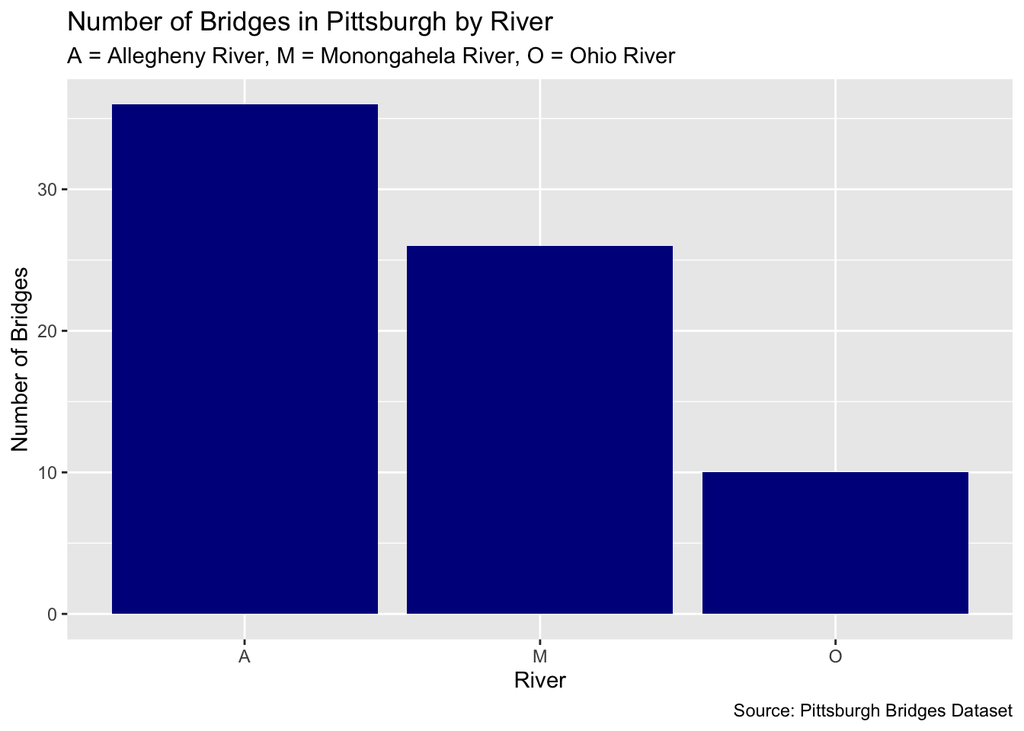

```r
# Create the bar plot
ggplot(bridges, aes(x = river)) +
 geom_bar(fill = "darkblue") +
 labs(
 title = "Number of Bridges in Pittsburgh by River",
 subtitle = "A = Allegheny River, M = Monongahela River, O = Ohio River",
 x = "River",
 y = "Number of Bridges",
 caption = "Source: Pittsburgh Bridges Dataset"
 )
```

Answer the following questions about the code and plot:

- In general, `ggplot()` code takes the following format: `ggplot(blank1, aes(x = blank2))`. Looking at the above code, what kind of `R` object should `blank1` be, and what should `blank2` be?

*`blank1` should be the dataset that you want to plot, and `blank2` should be the variable within that dataset you want to plot.*

- What do you think the line `geom_bar(fill = "darkblue")` does?

*It creates a bar plot where the bars are dark blue.*

- What do you think the remaining lines of code do (contained in `labs()`)?

*It creates “labels” for the plot - specifically, a title, subtitle, caption, and x-axis and y-axis labels.*

**Note that, unlike the code we saw in Problem 3, the dollar sign notation isn’t needed within `ggplot()`.**

4. (20pts) Now we’ll make a few other **area plots** we discussed in class:
- spine chart
- pie chart
- rose diagram

Your goal for this part is to create each of these plots. These plots can be created by copy-and-pasting the bar plot code from Part C and modifying it slightly. Follow these directions to create each of these plots:

- **spine chart**: First, copy-and-paste the bar plot code from Part C. Then, delete the `fill = "darkblue"` within `geom_bar()`. Finally, within `ggplot()`, replace `aes(x = river)` with `aes(x = "", fill = river)`. Also, change the labels in `labs()` if necessary.

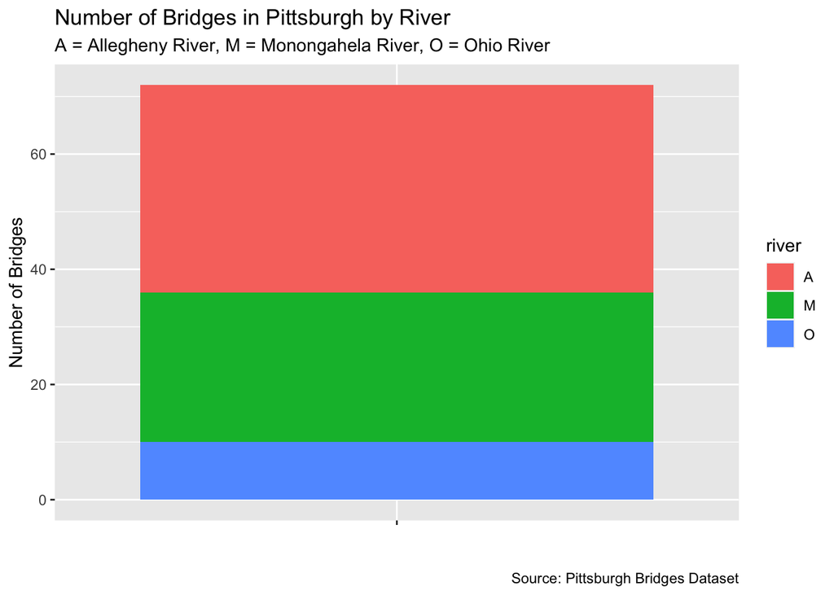

```r
# PUT YOUR SPINE CHART CODE HERE
ggplot(bridges, aes(x = "", fill = river)) +
 geom_bar() +
 labs(
 title = "Number of Bridges in Pittsburgh by River",
 subtitle = "A = Allegheny River, M = Monongahela River, O = Ohio River",
 x = "",
 y = "Number of Bridges",
 caption = "Source: Pittsburgh Bridges Dataset"
 )
```

- **pie chart**: First, copy-and-paste the **spine chart code** you just made. Then, after `geom_bar()`, “add” `coord_polar("y")`. Be sure to put plus signs before and after `coord_polar("y")`. Also, change the labels in `labs()` if necessary.

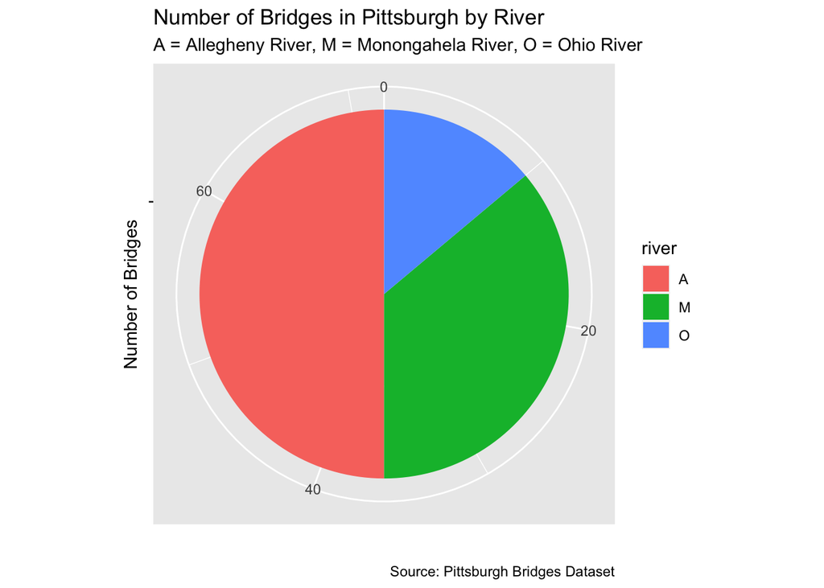

```r
# PUT YOUR PIE CHART CODE HERE
ggplot(bridges, aes(x = "", fill = river)) +
 geom_bar() + coord_polar("y") +
 labs(
 title = "Number of Bridges in Pittsburgh by River",
 subtitle = "A = Allegheny River, M = Monongahela River, O = Ohio River",
 x = "Number of Bridges",
 y = "",
 caption = "Source: Pittsburgh Bridges Dataset"
 )
```

- **rose diagram**: First, copy-and-paste the bar plot code from Part C. Then, after `geom_bar(fill = "darkblue")`, “add” `coord_polar() + scale_y_sqrt()`. Be sure to put plus signs before and after `coord_polar() + scale_y_sqrt()`. Also, change the labels in `labs()` if necessary. After you make the rose diagram: In 1-2 sentences, what do you think `scale_y_sqrt()` does, and what is a benefit to including `scale_y_sqrt()` when making the rose diagram?

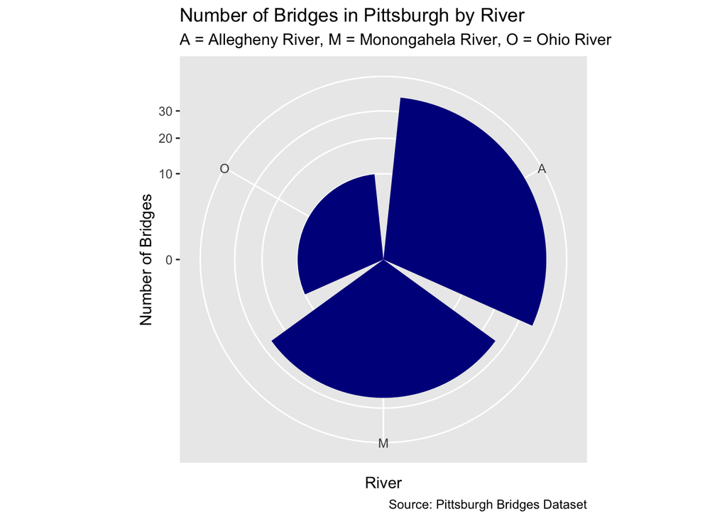

```r
# PUT YOUR ROSE DIAGRAM CODE HERE
ggplot(bridges, aes(x = river)) +
 geom_bar(fill = "darkblue") + coord_polar() + scale_y_sqrt() +
 labs(
 title = "Number of Bridges in Pittsburgh by River",
 subtitle = "A = Allegheny River, M = Monongahela River, O = Ohio River",
 x = "River",
 y = "Number of Bridges",
 caption = "Source: Pittsburgh Bridges Dataset"
 )
```

*The code `scale_y_sqrt()` makes it such that the radius of each “petal” is proportional to the square-root of the number of bridges in each category (instead of proportional to the number itself). This ensures that the area of each “petal” is proportional to the number of observations in each category, rather than the square of the number (as discussed in class).*

5. (5pts) Sometimes datasets don’t have every variable you want to visualize, in which case you have to create new columns in your data. Now we’ll use the `mutate()` function to create two new columns in the `bridges` dataset:
- `over_allegheny`: indicates whether the bridge crosses the Allegheny River (`"yes"` or `"no"`)
- `length_binary`: indicates whether the bridge is at least 1000 feet long (`"long"` or `"short"`)

Here’s some “template code” you can use to create these columns:

```r
# Create the new variables
bridges <- mutate(bridges,
   over_allegheny = ifelse(river ==  "A", "yes" , "no" ),
   length_binary = ifelse(length <  1000, "short" , "long" ))
```

**Note that the `mutate()` function is within the `tidyverse` library; so, remember that the above code runs only because you’ve already loaded the `tidyverse` library earlier in this .Rmd file.**

6. (10pts) The most common kind of summary statistic for a categorical variable is the counts of each category, often displayed as a **contingency table** (also known as a frequency table). To make a contingency table in `R`, you use the `table()` function. The following code should display a contingency table for the `length_binary` variable (after you’ve completed Part E):

```r
table(bridges$length_binary)
```

```
##
##  long short
##    61    11
```

Uncomment and run the above code and make sure a contingency table displays. Are there more `"long"` bridges or `"short"` bridges?

*As we can see, there are many more long bridges than short bridges.*

It can also be helpful to create a table of proportions, instead of a table of counts. Write a line of code that displays a table of proportions for the `bridges$length_binary` variable. In other words, your table should display the proportion of “short” and “long” bridges. To do this, you can either use the `prop.table()` function or the `table()` function (appropriately divided by a number).

*Here are two ways you could display the table of percentages:*

```r
#using prop.table() and table() together:
prop.table(table(bridges$length_binary))
```

```
##
##      long     short
## 0.8472222 0.1527778
```

```r
#using just table():
table(bridges$length_binary)/nrow(bridges)
```

```
##
##      long     short
## 0.8472222 0.1527778
```